# Universidade de Brasília

## Instituto de Física

### Métodos Computacionais A (MCA)

# **➲ AULA 20.12**

## Equações Diferenciais Ordinárias, Problemas de Valor Inicial e Problemas de Valor de Contorno

Em grande parte, o estudo da física é o estudo de equações diferenciais, então não é nenhuma surpresa que a solução numérica de equações diferenciais seja uma questão central na física computacional, uma vez que a experiência nos mostra que praticamente todas as equações interessantes não são triviais ou são impossíveis de resolver analiticamente.

Infelizmente, não existe um método melhor para resolver todas as equações diferenciais. Cada equação tem uma característica própria, e um método que funciona bem para uma equação pode funcionar mal, ou até mesmo falhar, para outra.

Já estudamos como obter soluções (raízes) de equações do tipo $ax + b = 0$ e $ax^2 + bx + c = 0$, onde $a$, $b$ e $c$ são constantes. Tais equações são conhecidas como equações algébricas e as incógnitas são números. Em uma equação diferencial, a incógnita é uma função. Uma equação diferencial geralmente envolve essa função e uma ou mais de suas derivadas. Quando essa função depende de uma única variável independente, a equação é chamada de **equação diferencial ordinária (EDO)**. Um exemplo bem simples de EDO é a equação $f'(x) = f(x)$. Este também é um exemplo de uma EDO de **primeira ordem**, já que a derivada mais alta que aparece na equação é uma derivada de primeira ordem. Quando a derivada mais alta em uma EDO é uma **segunda derivada**, temos uma EDO de **segunda ordem**, e assim por diante. Em geral, uma EDO pode ser escrita como:

$$ \frac{d^nf(x)}{dx^n} = F\left(x, f(x), \frac{df(x)}{dx}, \frac{d^2f(x)}{dx^2},\ldots,\frac{d^{n-1}f(x)}{dx^{n-1}}\right), $$

De tal modo que podemos escrever, simplificadamente, para uma equação de primeira ordem:

$$ y'(x) = f(x,y). $$

Como exemplo de equação de segunda ordem, vamos recordar que a equação de movimento de um pêndulo simples pode ser escrita como:

[figure not shown]

A equação de movimento de um pêndulo simples é um exemplo de EDO.  
Fonte: Burden, R.L.; Faires, J.D.; Burden, A.M. Numerical Analysis. Cengage Learning, 2015.

$$ \frac{d^2\theta}{dt^2} + \frac{g}{L}\text{sen}\,\theta=0. $$

Se estabelecermos duas condições iniciais para este problema, como, por exemplo, o ângulo e a velocidade angular inicial, teremos então um **Problema de Valor Inicial (PVI)** cuja solução não é mais uma família de funções mas sim uma função em particular (caso o problema seja bem-posto e admita solução única).

$$ \frac{d^2\theta}{dt^2} + \frac{g}{L}\text{sen}\,\theta=0, \qquad \theta(t_0)=\theta_0, \quad \theta'(t_0)=\theta_0'. $$

Se estabelecermos agora uma condição inicial e uma condição final, teremos então um **Problema de Valores de Contorno (PVC)**, e.g.:

$$ \frac{d^2\theta}{dt^2} + \frac{g}{L}\text{sen}\,\theta=0, \qquad \theta(t_0)=\theta_0, \quad \theta(t_n)=\theta_n. $$

## O Método de Euler

O método de Euler é um procedimento numérico de primeira ordem para solucionar equações diferenciais ordinárias com um valor inicial dado, isto é, para solucionar PVIs. É o tipo mais básico de método explícito para integração numérica para equações diferenciais ordinárias.

Suponha que queremos aproximar a solução de um problema de valor inicial:

$$ {\displaystyle y'(t)=f(t,y(t)),\qquad \qquad y(t_{0})=y_{0}.} $$

Para tanto vamos recordar da seguinte aproximação em série de Taylor em torno do ponto $x_i$:

$$ y(t_i+h) = y(t_i) + hy'(t_i) + \mathcal O(h) $$

Levando-se em consideração nossa EDO inicial, teremos que

$$ y_{i+1} \approx y_i + hf(t_i,y_i), $$

que a primeira aproximação da derivada para no método de Euler (vide figura abaixo).

[figure not shown]

O método de Euler utiliza os valores iniciais como primeira aproximação para a solução da equação diferencial ou PVI.

Vamos exemplificar o método com o seguinte PVI:

$$ y' = y - t^2 + 1,\quad 0 ≤ t ≤ 2,\quad y(0) = 0,5 $$

Note que $f(t,y) = y - t^2 + 1$. Tomaremos, inicialmente, $h=0,5$ a fim de obtermos as seguintes aproximações:

\begin{align*} y_0 &= y(0) = 0.5\\ y_1 &= y_0 + 0.5(y_0 − (0.0)^2 + 1) = 0.5 + 0.5(1.5) = 1.25\\ y_2 &= y_1 + 0.5(y_1 − (0.5)^2 + 1) = 1.25 + 0.5(2.0) = 2.25\\ y_3 &= y_2 + 0.5(y_2 − (1.0)^2 + 1) = 2.25 + 0.5(2.25) = 3.375\\ y_4 &= y_3 + 0.5(y_3 − (1.5)^2 + 1) = 3.375 + 0.5(2.125) = 4.4375 \end{align*}

Como $t_i = a +ih$, temos que $t_4 = 0 + 4h => t_4 = 2\,$s. Ou seja, $y_4 = y(2) = 4.4375$. O valor exato pode ser obtido da solução exata desta EDO:

$$ y(t) = (t + 1)^2 - 0.5\text{e}^t\\ y(2) = (2 + 1)^2 - 0.5\text{e}^2 \approx 5.3055\\ $$

Podemos reduzir o passo $h$ a fim de obter uma aproximação melhor com o método de Euler. Faremos isso utilizando Python:

```python
import math
import numpy as np

def f(t,y):
    return y - t*t + 1

def exata(t):
    return  (t + 1)**2 - 0.5*np.exp(t)

def euler(a, b, n, y0):
    t = np.linspace(a, b, n+1)
    h = t[1] - t[0]
    y = np.zeros(len(t))
    y[0] = y0
    for i in range(0, n):
        y[i+1] = y[i] + h*f(t[i], y[i])

    return t, y
```

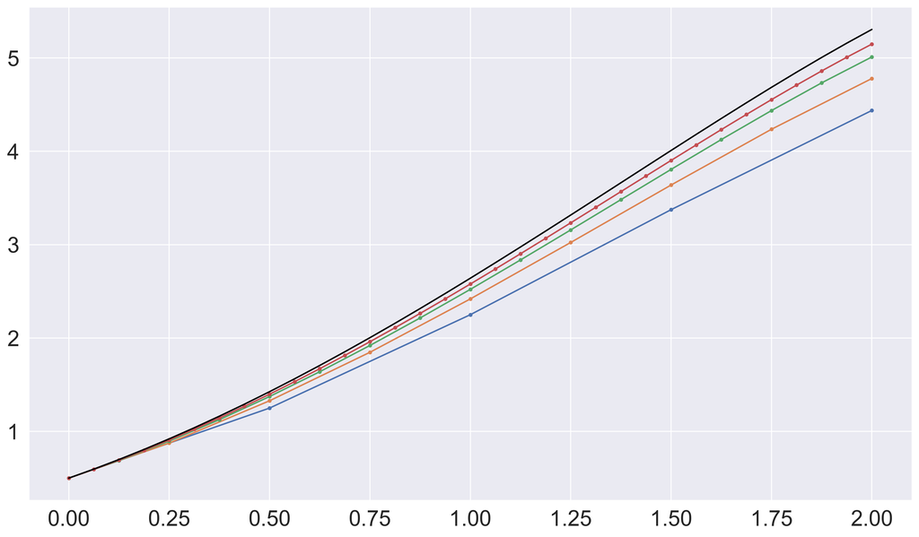

```python
from matplotlib import pyplot as plt
%matplotlib inline
import seaborn as sns
sns.set_theme()
sns.set(font="Verdana")
sns.set(font_scale=2)

a = 0
b = 2

ns = [2**i for i in range(2, 6)]
fig, ax = plt.subplots(figsize=(16,9), dpi=300)
for n in ns:
    t, y = euler(a, b, n, 0.5)
    ax.plot(t, y, marker=".")

t = np.linspace(a, b, n+1)
ax.plot(t, exata(t), color='black')
plt.show()
```

✎ EXERCÍCIO

Use o método de Euler para resolver o PVI:

\begin{cases} \displaystyle\frac{dy}{dx}= -1.2y + 7\text{e}^{-0.3x}\\ y(0) = 3 \end{cases}

Compare o resultado com a solução analítica:

$$ y = f(x) = \frac{70}{9}\text{e}^{-0.3x} - \frac{43}{9}\text{e}^{-1.2x}. $$

## Problema de Valor de Contorno

Continua na próxima aula...

```python
#@title
from IPython.display import HTML
from urllib.request import urlopen
script = urlopen("https://raw.githubusercontent.com/bgeneto/MCA/main/notebooks/_static/scripts.js")
html = script.read().decode('utf-8')
style = urlopen("https://raw.githubusercontent.com/bgeneto/MCA/main/notebooks/_static/styles.css")
html += style.read().decode('utf-8')
HTML(html)
```